# Introduction to summarytools

Dominic Comtois

2018-04-09

**`summarytools`** is an *R* package providing tools to neatly and quickly summarize data. It can also make *R* a little easier to learn and use.

An emphasis has been put on both *what* and *how* results are presented, so that the package can serve both as a data exploration *and* reporting tool, which can be used either on its own for minimal reports, or along with larger sets of tools such as RStudio’s for [rmarkdown](http://rmarkdown.rstudio.com/) and [knitr](https://yihui.name/knitr/).

## Four Core Functions

The package is built around four main functions:

- `freq()` : **Frequency tables** with proportions, cumulative proportions and missing data information
- `ctable()` : **Cross-Tabulations** with row, column, or total proportions, as well as marginal totals
- `descr()` : **Descriptive (univariate) statistics** for numerical vectors.
- `dfSummary()` – **Data frame summaries** that facilitate data cleaning and firsthand evaluation.

## Output Options

All `summarytools` objects returned by the main functions can be:

- Displayed as plain text in the console (default behavior)
- Redirected to plain text, *markdown/rmarkdown* or HTML documents
- Rendered to HTML and shown in default Web Browser or in *RStudio*’s Viewer

Text-based output relies on the pander package, while html output relies on RStudio’s htmltools.

## Bare-Bones Example: Frequency Table

To show what default (console) outputs look like, we’ll first generate a frequency table for `iris$Species`.

```r
freq(iris$Species)
```

```
Frequencies
Species
Data frame: iris
Type: Factor (unordered)

                   Freq   % Valid   % Valid Cum.   % Total   % Total Cum.
---------------- ------ --------- -------------- --------- --------------
          setosa     50     33.33          33.33     33.33          33.33
      versicolor     50     33.33          66.67     33.33          66.67
       virginica     50     33.33         100.00     33.33         100.00
            <NA>      0                               0.00         100.00
           Total    150    100.00         100.00    100.00         100.00
```

To get familiar with the output styles, try different values for `style=` and see how results look in the console.

### Markdown Outputs

When using `style='rmarkdown'` with `freq()` or `descr()`, the generated outputs are ready for markdown rendering. With `dfSummary()`, options for `style` are “multiline” (default) and “grid”, and `plain.ascii=FALSE` must be used to have proper line feeds in multiline cells.

**Note:** In an .Rmd document with `knitr`, always set the chunk option `results='asis'`:

````
```{r, results='asis'}
library(summarytools)
freq(tobacco$smoker, style='rmarkdown')
```
````

## Frequencies

**smoker**  
**Data frame:** tobacco  
**Type:** Factor (unordered)

|  | Freq | % Valid | % Valid Cum. | % Total | % Total Cum. |
| --- | --- | --- | --- | --- | --- |
| **Yes** | 298 | 29.80 | 29.80 | 29.80 | 29.80 |
| **No** | 702 | 70.20 | 100.00 | 70.20 | 100.00 |
| **<NA>** | 0 |  |  | 0.00 | 100.00 |
| **Total** | 1000 | 100.00 | 100.00 | 100.00 | 100.00 |

## Descriptive (Univariate) Statistics

The `descr()` function accepts both vectors and data frames, in which case it will show statistics for all numerical variables it contains. We’ll use one of the datasets included in the package.

```r
data(exams)
descr(exams[ ,3:5], style='rmarkdown')
```

### Descriptive Statistics

**Data Frame:** exams  
**N:** 30

|  | french | math | geography |
| --- | --- | --- | --- |
| **Mean** | 73.94 | 73.54 | 70.04 |
| **Std.Dev** | 10.79 | 9.19 | 10.65 |
| **Min** | 44.80 | 55.60 | 47.20 |
| **Q1** | 68.20 | 66.95 | 65.90 |
| **Median** | 73.60 | 73.75 | 68.50 |
| **Q3** | 76.70 | 80.35 | 77.80 |
| **Max** | 94.70 | 93.20 | 96.30 |
| **MAD** | 7.56 | 9.93 | 12.31 |
| **IQR** | 8.50 | 13.35 | 11.90 |
| **CV** | 6.85 | 8.00 | 6.58 |
| **Skewness** | 0.03 | 0.12 | 0.10 |
| **SE.Skewness** | 0.43 | 0.44 | 0.43 |
| **Kurtosis** | 0.45 | -0.58 | -0.03 |
| **N.Valid** | 29.00 | 28.00 | 29.00 |
| **Pct.Valid** | 96.67 | 93.33 | 96.67 |

To rather see variables in rows and stats in columns, use `transpose=TRUE`:

```r
descr(exams, style = 'rmarkdown', transpose = TRUE)
```

[output not shown]

### Cross-Tabulations

Let a few examples speak for themselves. First, a bare-bones cross-tabulation.

```r
with(tobacco, ctable(smoker, diseased, prop = 'n', totals = FALSE))
```

```
Cross-Tabulation
smoker * diseased
Data Frame: tobacco
-------- ---------- ----- -----
           diseased   Yes    No
  smoker
     Yes              125   173
      No               99   603
-------- ---------- ----- -----
```

Then show proportions, by row.

```r
with(tobacco, ctable(smoker, diseased, prop = 'r'))
```

```
Cross-Tabulation / Row proportions
smoker * diseased
Data Frame: tobacco
-------- ---------- -------------- -------------- ----------------
           diseased            Yes             No            Total
  smoker
     Yes              125 (41.95%)   173 (58.05%)    298 (100.00%)
      No               99 (14.10%)   603 (85.90%)    702 (100.00%)
   Total              224 (22.40%)   776 (77.60%)   1000 (100.00%)
-------- ---------- -------------- -------------- ----------------
```

The type of table generated by ctable() is unfortunately not (yet) supported by `rmarkdown`. But we can turn to the `render` method to circumvent this:

```r
crosstable <- with(tobacco, ctable(smoker, diseased))
print(crosstable, method='render', footnote = NA)
```

Cross-Tabulation / Row proportions

smoker * diseased

**Data Frame**: tobacco

| **smoker** | diseased Yes | diseased No | Total |
| --- | --- | --- | --- |
| **Yes** | 125 (41.95%) | 173 (58.05%) | 298 (100.00%) |
| **No** | 99 (14.10%) | 603 (85.90%) | 702 (100.00%) |
| **Total** | 224 (22.40%) | 776 (77.60%) | 1000 (100.00%) |

### Data frame Summaries

This is the most elaborate function of the package. It incorporates elements of freq() and descr(), but goes beyond with its graphs and other attributes.

```r
dfSummary(tobacco, style='grid', plain.ascii = FALSE)
```

## Data Frame Summary

**tobacco**  
**N:** 1000

| No | Variable | Stats / Values | Freqs (% of Valid) | Text Graph | Valid | Missing |
| --- | --- | --- | --- | --- | --- | --- |
| 1 | gender [factor] | 1. F 2. M | 489 (50.0%) 489 (50.0%) | IIIIIIIIIIIIIIII IIIIIIIIIIIIIIII | 978 (97.8%) | 22 (2.2%) |
| 2 | age [numeric] | mean (sd) : 49.6 (18.29) min < med < max : 18 < 50 < 80 IQR (CV) : 32 (0.37) | 63 distinct val. |  | 975 (97.5%) | 25 (2.5%) |
| 3 | age.gr [factor] | 1. 18-34 2. 35-50 3. 51-70 4. 71 + | 258 (26.5%) 241 (24.7%) 317 (32.5%) 159 (16.3%) | IIIIIIIIIIIII IIIIIIIIIIII IIIIIIIIIIIIIIII IIIIIIII | 975 (97.5%) | 25 (2.5%) |
| 4 | BMI [numeric] | mean (sd) : 25.73 (4.49) min < med < max : 8.83 < 25.62 < 39.44 IQR (CV) : 5.72 (0.17) | 974 distinct val. |  | 974 (97.4%) | 26 (2.6%) |
| 5 | smoker [factor] | 1. Yes 2. No | 298 (29.8%) 702 (70.2%) | IIIIII IIIIIIIIIIIIIIII | 1000 (100%) | 0 (0%) |
| 6 | cigs.per.day [numeric] | mean (sd) : 6.78 (11.88) min < med < max : 0 < 0 < 40 IQR (CV) : 11 (1.75) | 37 distinct val. |  | 965 (96.5%) | 35 (3.5%) |
| 7 | diseased [factor] | 1. Yes 2. No | 224 (22.4%) 776 (77.6%) | IIII IIIIIIIIIIIIIIII | 1000 (100%) | 0 (0%) |
| 8 | disease [character] | 1. Hypertension 2. Cancer 3. Cholesterol 4. Heart 5. Pulmonary 6. Musculoskeletal 7. Diabetes 8. Hearing 9. Digestive 10. Hypotension [ 3 others ] | 36 (16.2%) 34 (15.3%) 21 ( 9.5%) 20 ( 9.0%) 20 ( 9.0%) 19 ( 8.6%) 14 ( 6.3%) 14 ( 6.3%) 12 ( 5.4%) 11 ( 5.0%) 21 ( 9.4%) | IIIIIIIIIIIIIIII IIIIIIIIIIIIIII IIIIIIIII IIIIIIII IIIIIIII IIIIIIII IIIIII IIIIII IIIII IIII IIIIIIIII | 222 (22.2%) | 778 (77.8%) |
| 9 | samp.wgts [numeric] | mean (sd) : 1 (0.08) min < med < max : 0.86 < 1.04 < 1.06 IQR (CV) : 0.19 (0.08) | 0.86!: 267 (26.7%) 1.04!: 249 (24.9%) 1.05!: 324 (32.4%) 1.06!: 160 (16.0%) ! rounded | IIIIIIIIIIIII IIIIIIIIIIII IIIIIIIIIIIIIIII IIIIIII | 1000 (100%) | 0 (0%) |

For this one, we can use styles “multiline” (default) or “grid”. We **must** however specify `plain.ascii=FALSE` when using markdown, otherwise the rendered results will be problematic.

## Redirecting Output

### Text/Markdown Documents

Using the `file=` parameter with the `view()` or `print()` functions, we can redirect output into text files. And setting `append=TRUE` will append results to an existing text file:

```r
my_summary <- dfSummary(tobacco)
print(my_summary, file = "tobacco.txt", style = "grid")  # Creates tobacco.txt
my_stats <- descr(tobacco)
print(my_stats, file = "tobacco.txt", append = TRUE) # Appends results to tobacco.txt
```

As you may have noticed, the `style` argument was used when calling the `print()` function. We could also have used it when calling the `dfSummary()` and `descr()` functions, in which case the style would have been written in the objects’ properties. Using this argument with `print()` overrides the style that is stored in the object. It is one of several arguments that can be used that way. See the documentation for `print()` to know all the details.

### HTML Documents

`summarytools` uses [Bootstrap](http://getbootstrap.com/css/#tables)’s stylesheets to generate standalone HTML documents that can be displayed in a Web Browser or in *RStudio*’s Viewer using the generic `print()` function:

```r
print(dfSummary(tobacco), method = 'browser')  # Displays results in default Web Browser
print(dfSummary(tobacco), method = 'viewer')   # Displays results in RStudio's Viewer
view(dfSummary(tobacco))                       # Same as line above -- view() is a wrapper function
```

Using `file=` argument with an .html extension will simply generate an HTML document (without opening it).

```r
print(dfSummary(tobacco), file = '~/Documents/tobacco_summary.html')
```

Here is a picture of the output:

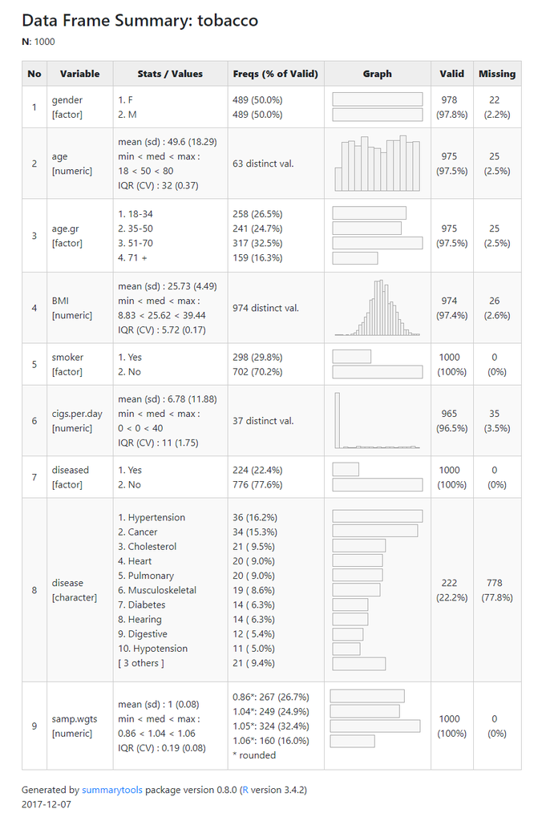

As with simple text files, you can also append existing HTML reports with additionnal content.

## Global options

Version 0.8.3 introduced the following set of global options:

- `round.digits` = `2`
- `plain.ascii` = `TRUE`
- `omit.headings` = `FALSE` (if using in a markdown document or a shiny app, setting this to `TRUE` might be preferable
- `footnote` = `'default'` (set to empty string or `NA` to omit footnote)
- `display.labels` = `TRUE`
- `freq.totals` = `TRUE`
- `freq.display.nas` = `TRUE`
- `ctable.totals` = `TRUE`
- `ctable.prop` = `'r'` (display *r*ow proportions by default)
- `descr.stats` = `'all'`
- `descr.transpose` = `FALSE`
- `bootstrap.css` = `TRUE` (if using in a markdown document or a shiny app, setting this to `FALSE` might be preferable
- `custom.css` = `NA`
- `escape.pipe` = `FALSE`

Examples:

```r
st_options() # display all global options' values
st_options('round.digits') # display only one option
st_options('round.digits', 1) # change an option's value
```

## Using by(), with(), and lapply()

Summarytools functions support the use of `by()`, `with()`, and `lapply()`, at least when used in good measure.

Since objects generated by those native functions have their own class (they are special lists containing summarytools objects), they are not sent to the package’s generic print method automatically. In order to have the best results, the following method is recommended: First, store the object generated by one of the native functions. Then, use `view()` either with `method='pander'` to show results in console, or omitting the `method` argument to see (HTML) results in the Viewer or Browser.

```r
stats <- by(data = exams$geography, INDICES = exams$gender, FUN = descr, style = 'rmarkdown')
view(stats, method = 'pander')
```

### Descriptive Statistics

**geography**  
**Data Frame:** exams  
**Group:** gender = Girl  
**N:** 15

|  | geography |
| --- | --- |
| **Mean** | 67.27 |
| **Std.Dev** | 8.26 |
| **Min** | 50.40 |
| **Q1** | 59.80 |
| **Median** | 67.30 |
| **Q3** | 73.60 |
| **Max** | 78.90 |
| **MAD** | 9.34 |
| **IQR** | 10.20 |
| **CV** | 8.14 |
| **Skewness** | -0.34 |
| **SE.Skewness** | 0.58 |
| **Kurtosis** | -0.90 |
| **N.Valid** | 15.00 |
| **Pct.Valid** | 100.00 |

**Group:** gender = Boy  
**N:** 15

|  | geography |
| --- | --- |
| **Mean** | 73.00 |
| **Std.Dev** | 12.35 |
| **Min** | 47.20 |
| **Q1** | 66.30 |
| **Median** | 71.20 |
| **Q3** | 82.70 |
| **Max** | 96.30 |
| **MAD** | 11.34 |
| **IQR** | 15.48 |
| **CV** | 5.91 |
| **Skewness** | -0.13 |
| **SE.Skewness** | 0.60 |
| **Kurtosis** | -0.48 |
| **N.Valid** | 14.00 |
| **Pct.Valid** | 93.33 |

## Things To Try Out

There are many things you can do to build elaborate, fine-tuned reports. Let’s mention a few…

- For HTML reports, footnotes can be customized or removed
- For text reports, captions can be added with the `caption=` argument
- Text files as well as HTML files can be appended with as many results you need
- Custom CSS can be added – you can specify custom classes for any table you generate For example, to add the Bootstrap `table-responsive` and the summarytools `st-small` classes:

```r
with(tobacco, view(ctable(gender, smoker)),
     report.title = "Summary of the tobacco sample data frame",
     table.classes = "table-responsive st-small",
     footnote = "Extended use of Bootstrap classes")
```

## Getting Most Properties of an Object With `what.is()`

When developing, we often use a number functions to obtain an object’s properties. `what.is()` proposes to lump together the results of such functions (`class()`, `typeof()`, `attributes()` and others).

```r
what.is(iris)
```

```
$properties
      property      value
1        class data.frame
2       typeof       list
3         mode       list
4 storage.mode       list
5          dim    150 x 5
6       length          5
7    is.object       TRUE
8  object.type         S3
9  object.size 7088 Bytes

$attributes.lengths
    names row.names     class
        5       150         1

$extensive.is
[1] "is.data.frame" "is.list"       "is.object"     "is.recursive"
[5] "is.unsorted"
```

## Limitations

- The text histograms in dfSummary are not yet supported in `rmarkdown`
- It is not possible to control the heading levels of individual items

## Learn More and Stay Up-to-date

Check the [project’s page](https://github.com/dcomtois/summarytools) for more examples; from there you can also submit feature requests or signal problems you might encounter.

To install the package in its development version, use

```r
install.packages('devtools')
library(devtools)
install_github('dcomtois/summarytools', ref='dev-current')
```

### Final note

The source of this document is an .Rmd file; `knitr`’s chunk option `results` has been set to `'asis'`, to make sure formatting is not coming from `knitr` itself.